# Risk Factor Analysis

## Outcome Variable

**Outcome Variable:** haz

## Predictor Variables

**Intervention Variable:** meducyrs

**Adjustment Set:**

- arm
- W_mage
- feducyrs
- W_mhtcm
- single
- W_nrooms
- impsan
- W_gagebrth
- W_birthwt
- W_birthlen
- vagbrth
- parity
- delta_W_mage
- delta_feducyrs
- delta_W_mhtcm
- delta_single
- delta_W_nrooms
- delta_impsan
- delta_W_gagebrth
- delta_W_birthwt
- delta_W_birthlen
- delta_vagbrth
- delta_parity

## Stratifying Variables

The analysis was stratified on these variable(s):

- agecat
- studyid
- country

## Data Summary

| agecat | studyid | country | meducyrs | n_cell | n |
| --- | --- | --- | --- | --- | --- |
| 6 months | ki0047075b-MAL-ED | BANGLADESH | High | 73 | 196 |
| 6 months | ki0047075b-MAL-ED | BANGLADESH | Low | 64 | 196 |
| 6 months | ki0047075b-MAL-ED | BANGLADESH | Medium | 59 | 196 |
| 6 months | ki0047075b-MAL-ED | BRAZIL | High | 71 | 208 |
| 6 months | ki0047075b-MAL-ED | BRAZIL | Low | 56 | 208 |
| 6 months | ki0047075b-MAL-ED | BRAZIL | Medium | 81 | 208 |
| 6 months | ki0047075b-MAL-ED | INDIA | High | 59 | 208 |
| 6 months | ki0047075b-MAL-ED | INDIA | Low | 72 | 208 |
| 6 months | ki0047075b-MAL-ED | INDIA | Medium | 77 | 208 |
| 6 months | ki0047075b-MAL-ED | NEPAL | High | 53 | 221 |
| 6 months | ki0047075b-MAL-ED | NEPAL | Low | 93 | 221 |
| 6 months | ki0047075b-MAL-ED | NEPAL | Medium | 75 | 221 |
| 6 months | ki0047075b-MAL-ED | PERU | High | 81 | 272 |
| 6 months | ki0047075b-MAL-ED | PERU | Low | 94 | 272 |
| 6 months | ki0047075b-MAL-ED | PERU | Medium | 97 | 272 |
| 6 months | ki0047075b-MAL-ED | SOUTH AFRICA | High | 70 | 254 |
| 6 months | ki0047075b-MAL-ED | SOUTH AFRICA | Low | 127 | 254 |
| 6 months | ki0047075b-MAL-ED | SOUTH AFRICA | Medium | 57 | 254 |
| 6 months | ki0047075b-MAL-ED | TANZANIA, UNITED REPUBLIC OF | High | 9 | 203 |
| 6 months | ki0047075b-MAL-ED | TANZANIA, UNITED REPUBLIC OF | Low | 62 | 203 |
| 6 months | ki0047075b-MAL-ED | TANZANIA, UNITED REPUBLIC OF | Medium | 132 | 203 |
| 6 months | ki1000108-CMC-V-BCS-2002 | INDIA | High | 157 | 369 |
| 6 months | ki1000108-CMC-V-BCS-2002 | INDIA | Low | 105 | 369 |
| 6 months | ki1000108-CMC-V-BCS-2002 | INDIA | Medium | 107 | 369 |
| 6 months | ki1000108-IRC | INDIA | High | 123 | 407 |
| 6 months | ki1000108-IRC | INDIA | Low | 146 | 407 |
| 6 months | ki1000108-IRC | INDIA | Medium | 138 | 407 |
| 6 months | ki1000109-EE | PAKISTAN | High | 15 | 369 |
| 6 months | ki1000109-EE | PAKISTAN | Low | 321 | 369 |
| 6 months | ki1000109-EE | PAKISTAN | Medium | 33 | 369 |

[output cut: 114 more lines]

The following strata were considered:

- agecat: 24 months, studyid: ki0047075b-MAL-ED, country: BANGLADESH
- agecat: 24 months, studyid: ki0047075b-MAL-ED, country: BRAZIL
- agecat: 24 months, studyid: ki0047075b-MAL-ED, country: INDIA
- agecat: 24 months, studyid: ki0047075b-MAL-ED, country: NEPAL
- agecat: 24 months, studyid: ki0047075b-MAL-ED, country: PERU
- agecat: 24 months, studyid: ki0047075b-MAL-ED, country: SOUTH AFRICA
- agecat: 24 months, studyid: ki0047075b-MAL-ED, country: TANZANIA, UNITED REPUBLIC OF
- agecat: 24 months, studyid: ki1000108-CMC-V-BCS-2002, country: INDIA
- agecat: 24 months, studyid: ki1000108-IRC, country: INDIA
- agecat: 24 months, studyid: ki1017093-NIH-Birth, country: BANGLADESH
- agecat: 24 months, studyid: ki1017093b-PROVIDE, country: BANGLADESH
- agecat: 24 months, studyid: ki1017093c-NIH-Crypto, country: BANGLADESH
- agecat: 24 months, studyid: ki1066203-TanzaniaChild2, country: TANZANIA, UNITED REPUBLIC OF
- agecat: 24 months, studyid: ki1113344-GMS-Nepal, country: NEPAL
- agecat: 24 months, studyid: ki1119695-PROBIT, country: BELARUS
- agecat: 24 months, studyid: ki1126311-ZVITAMBO, country: ZIMBABWE
- agecat: 24 months, studyid: ki1135781-COHORTS, country: GUATEMALA
- agecat: 24 months, studyid: ki1135781-COHORTS, country: INDIA
- agecat: 24 months, studyid: ki1135781-COHORTS, country: PHILIPPINES
- agecat: 24 months, studyid: ki1148112-LCNI-5, country: MALAWI
- agecat: 24 months, studyid: kiGH5241-JiVitA-3, country: BANGLADESH
- agecat: 24 months, studyid: kiGH5241-JiVitA-4, country: BANGLADESH
- agecat: 6 months, studyid: ki0047075b-MAL-ED, country: BANGLADESH
- agecat: 6 months, studyid: ki0047075b-MAL-ED, country: BRAZIL
- agecat: 6 months, studyid: ki0047075b-MAL-ED, country: INDIA
- agecat: 6 months, studyid: ki0047075b-MAL-ED, country: NEPAL
- agecat: 6 months, studyid: ki0047075b-MAL-ED, country: PERU
- agecat: 6 months, studyid: ki0047075b-MAL-ED, country: SOUTH AFRICA
- agecat: 6 months, studyid: ki0047075b-MAL-ED, country: TANZANIA, UNITED REPUBLIC OF
- agecat: 6 months, studyid: ki1000108-CMC-V-BCS-2002, country: INDIA
- agecat: 6 months, studyid: ki1000108-IRC, country: INDIA
- agecat: 6 months, studyid: ki1000109-EE, country: PAKISTAN
- agecat: 6 months, studyid: ki1000304b-SAS-CompFeed, country: INDIA
- agecat: 6 months, studyid: ki1000304b-SAS-FoodSuppl, country: INDIA
- agecat: 6 months, studyid: ki1017093-NIH-Birth, country: BANGLADESH
- agecat: 6 months, studyid: ki1017093b-PROVIDE, country: BANGLADESH
- agecat: 6 months, studyid: ki1017093c-NIH-Crypto, country: BANGLADESH
- agecat: 6 months, studyid: ki1066203-TanzaniaChild2, country: TANZANIA, UNITED REPUBLIC OF
- agecat: 6 months, studyid: ki1112895-Guatemala BSC, country: GUATEMALA
- agecat: 6 months, studyid: ki1113344-GMS-Nepal, country: NEPAL
- agecat: 6 months, studyid: ki1119695-PROBIT, country: BELARUS
- agecat: 6 months, studyid: ki1126311-ZVITAMBO, country: ZIMBABWE
- agecat: 6 months, studyid: ki1135781-COHORTS, country: GUATEMALA
- agecat: 6 months, studyid: ki1135781-COHORTS, country: INDIA
- agecat: 6 months, studyid: ki1135781-COHORTS, country: PHILIPPINES
- agecat: 6 months, studyid: ki1148112-LCNI-5, country: MALAWI
- agecat: 6 months, studyid: kiGH5241-JiVitA-3, country: BANGLADESH
- agecat: 6 months, studyid: kiGH5241-JiVitA-4, country: BANGLADESH

### Dropped Strata

Some strata were dropped due to rare outcomes:

## Methods Detail

We’re interested in the causal parameters $E[Y_a]$ for all values of $a \in \mathcal{A}$. These parameters represent the mean outcome if, possibly contrary to fact, we intervened to set all units to have $A=a$. Under the randomization and positivity assumptions, these are identified by the statistical parameters $\psi_a=E_W[E_{Y|A,W}(Y|A=a,W)]$. In addition, we’re interested in the mean of $Y$, $E[Y]$ under no intervention (the observed mean). We will estimate these parameters by using SuperLearner to fit the relevant likelihood factors – $E_{Y|A,W}(Y|A=a,W)$ and $p(A=a|W)$, and then updating our likelihood fit using a joint TMLE.

For unadjusted analyses ($W=\{\}$), initial likelihoods were estimated using Lrnr_glm to estimate the simple $E(Y|A)$ and Lrnr_mean to estimate $p(A)$. For adjusted analyses, a small library containing Lrnr_glmnet, Lrnr_xgboost, and Lrnr_mean was used.

Having estimated these parameters, we will then use the delta method to estimate relative risks and attributable risks relative to a prespecified baseline level of $A$.

# Results Detail

## Results Plots

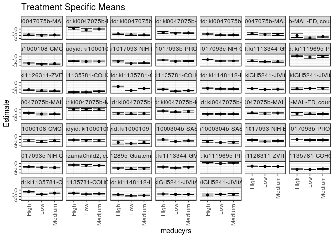

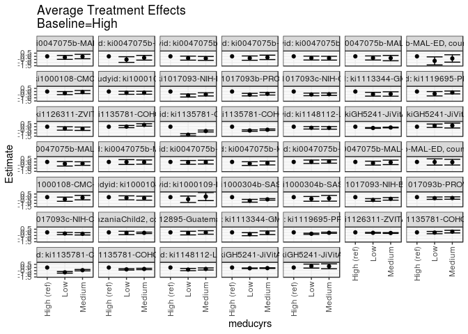

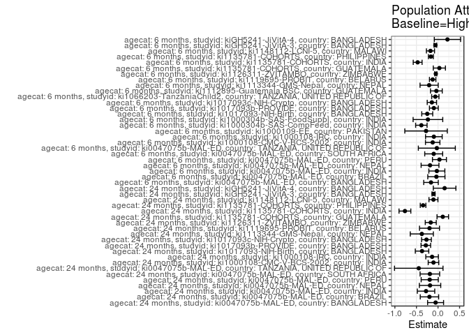

## Results Table

### Parameter: TSM

| agecat | studyid | country | intervention_level | baseline_level | estimate | ci_lower | ci_upper |
| --- | --- | --- | --- | --- | --- | --- | --- |
| 6 months | ki0047075b-MAL-ED | BANGLADESH | High | NA | -1.0308174 | -1.2273371 | -0.8342977 |
| 6 months | ki0047075b-MAL-ED | BANGLADESH | Low | NA | -1.3306419 | -1.6292585 | -1.0320252 |
| 6 months | ki0047075b-MAL-ED | BANGLADESH | Medium | NA | -1.2918527 | -1.4967862 | -1.0869192 |
| 6 months | ki0047075b-MAL-ED | BRAZIL | High | NA | 0.0908845 | -0.1494134 | 0.3311824 |
| 6 months | ki0047075b-MAL-ED | BRAZIL | Low | NA | 0.0734005 | -0.2248351 | 0.3716362 |
| 6 months | ki0047075b-MAL-ED | BRAZIL | Medium | NA | 0.0657051 | -0.1649584 | 0.2963686 |
| 6 months | ki0047075b-MAL-ED | INDIA | High | NA | -1.1433805 | -1.3546749 | -0.9320860 |
| 6 months | ki0047075b-MAL-ED | INDIA | Low | NA | -1.2144351 | -1.4300136 | -0.9988567 |
| 6 months | ki0047075b-MAL-ED | INDIA | Medium | NA | -1.1746322 | -1.3836267 | -0.9656377 |
| 6 months | ki0047075b-MAL-ED | NEPAL | High | NA | -0.3632860 | -0.5988133 | -0.1277586 |
| 6 months | ki0047075b-MAL-ED | NEPAL | Low | NA | -0.6244393 | -0.8030695 | -0.4458090 |
| 6 months | ki0047075b-MAL-ED | NEPAL | Medium | NA | -0.5388933 | -0.7289691 | -0.3488175 |
| 6 months | ki0047075b-MAL-ED | PERU | High | NA | -1.3642403 | -1.5538030 | -1.1746776 |
| 6 months | ki0047075b-MAL-ED | PERU | Low | NA | -1.3374971 | -1.5274965 | -1.1474977 |
| 6 months | ki0047075b-MAL-ED | PERU | Medium | NA | -1.2993788 | -1.4836485 | -1.1151091 |
| 6 months | ki0047075b-MAL-ED | SOUTH AFRICA | High | NA | -0.9634520 | -1.2028622 | -0.7240418 |
| 6 months | ki0047075b-MAL-ED | SOUTH AFRICA | Low | NA | -1.1522064 | -1.3498590 | -0.9545539 |
| 6 months | ki0047075b-MAL-ED | SOUTH AFRICA | Medium | NA | -1.0339077 | -1.2909738 | -0.7768416 |
| 6 months | ki0047075b-MAL-ED | TANZANIA, UNITED REPUBLIC OF | High | NA | -1.2557407 | -1.6831816 | -0.8282999 |
| 6 months | ki0047075b-MAL-ED | TANZANIA, UNITED REPUBLIC OF | Low | NA | -1.2635215 | -1.5158232 | -1.0112198 |
| 6 months | ki0047075b-MAL-ED | TANZANIA, UNITED REPUBLIC OF | Medium | NA | -1.2943939 | -1.4544477 | -1.1343401 |
| 6 months | ki1000108-CMC-V-BCS-2002 | INDIA | High | NA | -1.2998900 | -1.5184571 | -1.0813229 |
| 6 months | ki1000108-CMC-V-BCS-2002 | INDIA | Low | NA | -1.6322591 | -1.8817473 | -1.3827708 |
| 6 months | ki1000108-CMC-V-BCS-2002 | INDIA | Medium | NA | -1.3764920 | -1.6568601 | -1.0961239 |
| 6 months | ki1000108-IRC | INDIA | High | NA | -1.1381568 | -1.3602885 | -0.9160251 |
| 6 months | ki1000108-IRC | INDIA | Low | NA | -1.2472723 | -1.4755966 | -1.0189481 |
| 6 months | ki1000108-IRC | INDIA | Medium | NA | -1.3012335 | -1.5272856 | -1.0751814 |
| 6 months | ki1000109-EE | PAKISTAN | High | NA | -1.9183983 | -2.4143457 | -1.4224509 |
| 6 months | ki1000109-EE | PAKISTAN | Low | NA | -2.2558086 | -2.3893999 | -2.1222173 |
| 6 months | ki1000109-EE | PAKISTAN | Medium | NA | -1.8245007 | -2.2314901 | -1.4175113 |

[output cut: 111 more lines]

### Parameter: E(Y)

| agecat | studyid | country | intervention_level | baseline_level | estimate | ci_lower | ci_upper |
| --- | --- | --- | --- | --- | --- | --- | --- |
| 6 months | ki0047075b-MAL-ED | BANGLADESH | NA | NA | -1.1935544 | -1.3251572 | -1.0619516 |
| 6 months | ki0047075b-MAL-ED | BRAZIL | NA | NA | 0.0529327 | -0.0917526 | 0.1976180 |
| 6 months | ki0047075b-MAL-ED | INDIA | NA | NA | -1.1704327 | -1.2921639 | -1.0487015 |
| 6 months | ki0047075b-MAL-ED | NEPAL | NA | NA | -0.5483560 | -0.6619002 | -0.4348118 |
| 6 months | ki0047075b-MAL-ED | PERU | NA | NA | -1.3312377 | -1.4396065 | -1.2228689 |
| 6 months | ki0047075b-MAL-ED | SOUTH AFRICA | NA | NA | -1.0633760 | -1.1911088 | -0.9356432 |
| 6 months | ki0047075b-MAL-ED | TANZANIA, UNITED REPUBLIC OF | NA | NA | -1.2832512 | -1.4141440 | -1.1523584 |
| 6 months | ki1000108-CMC-V-BCS-2002 | INDIA | NA | NA | -1.4234508 | -1.5645974 | -1.2823042 |
| 6 months | ki1000108-IRC | INDIA | NA | NA | -1.2344062 | -1.3658524 | -1.1029600 |
| 6 months | ki1000109-EE | PAKISTAN | NA | NA | -2.1956098 | -2.3191627 | -2.0720568 |
| 6 months | ki1000304b-SAS-CompFeed | INDIA | NA | NA | -1.4018563 | -1.4810585 | -1.3226541 |
| 6 months | ki1000304b-SAS-FoodSuppl | INDIA | NA | NA | -1.8986842 | -2.0118892 | -1.7854792 |
| 6 months | ki1017093-NIH-Birth | BANGLADESH | NA | NA | -1.4073821 | -1.4960598 | -1.3187043 |
| 6 months | ki1017093b-PROVIDE | BANGLADESH | NA | NA | -1.0871041 | -1.1635539 | -1.0106543 |
| 6 months | ki1017093c-NIH-Crypto | BANGLADESH | NA | NA | -1.1986783 | -1.2700937 | -1.1272630 |
| 6 months | ki1066203-TanzaniaChild2 | TANZANIA, UNITED REPUBLIC OF | NA | NA | -0.5440108 | -0.5930025 | -0.4950192 |
| 6 months | ki1112895-Guatemala BSC | GUATEMALA | NA | NA | -1.5624368 | -1.6783540 | -1.4465196 |
| 6 months | ki1113344-GMS-Nepal | NEPAL | NA | NA | -1.3322083 | -1.4107364 | -1.2536803 |
| 6 months | ki1119695-PROBIT | BELARUS | NA | NA | 0.1069986 | 0.0122286 | 0.2017686 |
| 6 months | ki1126311-ZVITAMBO | ZIMBABWE | NA | NA | -0.8916958 | -0.9176814 | -0.8657103 |
| 6 months | ki1135781-COHORTS | GUATEMALA | NA | NA | -1.8103361 | -1.8786415 | -1.7420307 |
| 6 months | ki1135781-COHORTS | INDIA | NA | NA | -1.0183078 | -1.0495042 | -0.9871113 |
| 6 months | ki1135781-COHORTS | PHILIPPINES | NA | NA | -1.1405724 | -1.1824954 | -1.0986493 |
| 6 months | ki1148112-LCNI-5 | MALAWI | NA | NA | -1.6431488 | -1.7125598 | -1.5737379 |
| 6 months | kiGH5241-JiVitA-3 | BANGLADESH | NA | NA | -1.3131339 | -1.3362896 | -1.2899781 |
| 6 months | kiGH5241-JiVitA-4 | BANGLADESH | NA | NA | -1.3385142 | -1.3948471 | -1.2821814 |
| 24 months | ki0047075b-MAL-ED | BANGLADESH | NA | NA | -1.8744152 | -2.0076626 | -1.7411678 |
| 24 months | ki0047075b-MAL-ED | BRAZIL | NA | NA | 0.0434524 | -0.1247334 | 0.2116382 |
| 24 months | ki0047075b-MAL-ED | INDIA | NA | NA | -1.7845980 | -1.9142624 | -1.6549336 |
| 24 months | ki0047075b-MAL-ED | NEPAL | NA | NA | -1.2366901 | -1.3594733 | -1.1139070 |
| 24 months | ki0047075b-MAL-ED | PERU | NA | NA | -1.7521250 | -1.8731109 | -1.6311391 |
| 24 months | ki0047075b-MAL-ED | SOUTH AFRICA | NA | NA | -1.6228361 | -1.7581177 | -1.4875546 |
| 24 months | ki0047075b-MAL-ED | TANZANIA, UNITED REPUBLIC OF | NA | NA | -2.5264286 | -2.6690955 | -2.3837616 |
| 24 months | ki1000108-CMC-V-BCS-2002 | INDIA | NA | NA | -2.5593683 | -2.6601027 | -2.4586339 |
| 24 months | ki1000108-IRC | INDIA | NA | NA | -1.7824776 | -1.8765600 | -1.6883952 |
| 24 months | ki1017093-NIH-Birth | BANGLADESH | NA | NA | -2.1807945 | -2.2835902 | -2.0779987 |
| 24 months | ki1017093b-PROVIDE | BANGLADESH | NA | NA | -1.5861179 | -1.6693668 | -1.5028689 |
| 24 months | ki1017093c-NIH-Crypto | BANGLADESH | NA | NA | -1.4295331 | -1.5127726 | -1.3462935 |
| 24 months | ki1113344-GMS-Nepal | NEPAL | NA | NA | -1.8849429 | -1.9699639 | -1.7999219 |
| 24 months | ki1119695-PROBIT | BELARUS | NA | NA | -0.1314048 | -0.4282725 | 0.1654630 |
| 24 months | ki1126311-ZVITAMBO | ZIMBABWE | NA | NA | -2.3994530 | -2.5144490 | -2.2844569 |
| 24 months | ki1135781-COHORTS | GUATEMALA | NA | NA | -2.8575660 | -2.9223159 | -2.7928162 |
| 24 months | ki1135781-COHORTS | INDIA | NA | NA | -1.9615163 | -1.9983763 | -1.9246563 |
| 24 months | ki1135781-COHORTS | PHILIPPINES | NA | NA | -2.3898650 | -2.4346888 | -2.3450412 |
| 24 months | ki1148112-LCNI-5 | MALAWI | NA | NA | -1.8686713 | -1.9502344 | -1.7871083 |
| 24 months | kiGH5241-JiVitA-3 | BANGLADESH | NA | NA | -2.0124336 | -2.0401325 | -1.9847347 |
| 24 months | kiGH5241-JiVitA-4 | BANGLADESH | NA | NA | -1.7686889 | -1.8213457 | -1.7160321 |

### Parameter: ATE

| agecat | studyid | country | intervention_level | baseline_level | estimate | ci_lower | ci_upper |
| --- | --- | --- | --- | --- | --- | --- | --- |
| 6 months | ki0047075b-MAL-ED | BANGLADESH | High | High | 0.0000000 | 0.0000000 | 0.0000000 |
| 6 months | ki0047075b-MAL-ED | BANGLADESH | Low | High | -0.2998245 | -0.6578388 | 0.0581899 |
| 6 months | ki0047075b-MAL-ED | BANGLADESH | Medium | High | -0.2610353 | -0.5457391 | 0.0236685 |
| 6 months | ki0047075b-MAL-ED | BRAZIL | High | High | 0.0000000 | 0.0000000 | 0.0000000 |
| 6 months | ki0047075b-MAL-ED | BRAZIL | Low | High | -0.0174840 | -0.3999950 | 0.3650270 |
| 6 months | ki0047075b-MAL-ED | BRAZIL | Medium | High | -0.0251794 | -0.3586474 | 0.3082885 |
| 6 months | ki0047075b-MAL-ED | INDIA | High | High | 0.0000000 | 0.0000000 | 0.0000000 |
| 6 months | ki0047075b-MAL-ED | INDIA | Low | High | -0.0710546 | -0.3731285 | 0.2310192 |
| 6 months | ki0047075b-MAL-ED | INDIA | Medium | High | -0.0312517 | -0.3288439 | 0.2663405 |
| 6 months | ki0047075b-MAL-ED | NEPAL | High | High | 0.0000000 | 0.0000000 | 0.0000000 |
| 6 months | ki0047075b-MAL-ED | NEPAL | Low | High | -0.2611533 | -0.5549968 | 0.0326902 |
| 6 months | ki0047075b-MAL-ED | NEPAL | Medium | High | -0.1756073 | -0.4799643 | 0.1287496 |
| 6 months | ki0047075b-MAL-ED | PERU | High | High | 0.0000000 | 0.0000000 | 0.0000000 |
| 6 months | ki0047075b-MAL-ED | PERU | Low | High | 0.0267432 | -0.2414771 | 0.2949635 |
| 6 months | ki0047075b-MAL-ED | PERU | Medium | High | 0.0648615 | -0.1994138 | 0.3291369 |
| 6 months | ki0047075b-MAL-ED | SOUTH AFRICA | High | High | 0.0000000 | 0.0000000 | 0.0000000 |
| 6 months | ki0047075b-MAL-ED | SOUTH AFRICA | Low | High | -0.1887544 | -0.4988733 | 0.1213645 |
| 6 months | ki0047075b-MAL-ED | SOUTH AFRICA | Medium | High | -0.0704557 | -0.4225481 | 0.2816366 |
| 6 months | ki0047075b-MAL-ED | TANZANIA, UNITED REPUBLIC OF | High | High | 0.0000000 | 0.0000000 | 0.0000000 |
| 6 months | ki0047075b-MAL-ED | TANZANIA, UNITED REPUBLIC OF | Low | High | -0.0077808 | -0.5041292 | 0.4885677 |
| 6 months | ki0047075b-MAL-ED | TANZANIA, UNITED REPUBLIC OF | Medium | High | -0.0386532 | -0.4950772 | 0.4177708 |
| 6 months | ki1000108-CMC-V-BCS-2002 | INDIA | High | High | 0.0000000 | 0.0000000 | 0.0000000 |
| 6 months | ki1000108-CMC-V-BCS-2002 | INDIA | Low | High | -0.3323691 | -0.6632333 | -0.0015049 |
| 6 months | ki1000108-CMC-V-BCS-2002 | INDIA | Medium | High | -0.0766020 | -0.4313525 | 0.2781484 |
| 6 months | ki1000108-IRC | INDIA | High | High | 0.0000000 | 0.0000000 | 0.0000000 |
| 6 months | ki1000108-IRC | INDIA | Low | High | -0.1091155 | -0.4284470 | 0.2102159 |
| 6 months | ki1000108-IRC | INDIA | Medium | High | -0.1630767 | -0.4787438 | 0.1525905 |
| 6 months | ki1000109-EE | PAKISTAN | High | High | 0.0000000 | 0.0000000 | 0.0000000 |
| 6 months | ki1000109-EE | PAKISTAN | Low | High | -0.3374103 | -0.8506015 | 0.1757808 |
| 6 months | ki1000109-EE | PAKISTAN | Medium | High | 0.0938976 | -0.5494004 | 0.7371956 |

[output cut: 111 more lines]

### Parameter: PAR

| agecat | studyid | country | intervention_level | baseline_level | estimate | ci_lower | ci_upper |
| --- | --- | --- | --- | --- | --- | --- | --- |
| 6 months | ki0047075b-MAL-ED | BANGLADESH | High | NA | -0.1627370 | -0.3313538 | 0.0058797 |
| 6 months | ki0047075b-MAL-ED | BRAZIL | High | NA | -0.0379518 | -0.2370957 | 0.1611921 |
| 6 months | ki0047075b-MAL-ED | INDIA | High | NA | -0.0270522 | -0.2123516 | 0.1582471 |
| 6 months | ki0047075b-MAL-ED | NEPAL | High | NA | -0.1850700 | -0.3916393 | 0.0214993 |
| 6 months | ki0047075b-MAL-ED | PERU | High | NA | 0.0330026 | -0.1288028 | 0.1948079 |
| 6 months | ki0047075b-MAL-ED | SOUTH AFRICA | High | NA | -0.0999240 | -0.3078622 | 0.1080142 |
| 6 months | ki0047075b-MAL-ED | TANZANIA, UNITED REPUBLIC OF | High | NA | -0.0275105 | -0.4560406 | 0.4010196 |
| 6 months | ki1000108-CMC-V-BCS-2002 | INDIA | High | NA | -0.1235608 | -0.2910991 | 0.0439775 |
| 6 months | ki1000108-IRC | INDIA | High | NA | -0.0962494 | -0.2889267 | 0.0964279 |
| 6 months | ki1000109-EE | PAKISTAN | High | NA | -0.2772115 | -0.7699141 | 0.2154912 |
| 6 months | ki1000304b-SAS-CompFeed | INDIA | High | NA | -0.3862288 | -0.5187966 | -0.2536611 |
| 6 months | ki1000304b-SAS-FoodSuppl | INDIA | High | NA | -0.2338127 | -0.5773787 | 0.1097533 |
| 6 months | ki1017093-NIH-Birth | BANGLADESH | High | NA | -0.2496598 | -0.3766278 | -0.1226917 |
| 6 months | ki1017093b-PROVIDE | BANGLADESH | High | NA | -0.0964026 | -0.1985224 | 0.0057171 |
| 6 months | ki1017093c-NIH-Crypto | BANGLADESH | High | NA | -0.1422421 | -0.2504144 | -0.0340697 |
| 6 months | ki1066203-TanzaniaChild2 | TANZANIA, UNITED REPUBLIC OF | High | NA | -0.0624251 | -0.1469352 | 0.0220849 |
| 6 months | ki1112895-Guatemala BSC | GUATEMALA | High | NA | -0.0383479 | -0.1743500 | 0.0976542 |
| 6 months | ki1113344-GMS-Nepal | NEPAL | High | NA | -0.2060274 | -0.4165359 | 0.0044811 |
| 6 months | ki1119695-PROBIT | BELARUS | High | NA | -0.1240305 | -0.1984446 | -0.0496163 |
| 6 months | ki1126311-ZVITAMBO | ZIMBABWE | High | NA | -0.0516266 | -0.0754913 | -0.0277618 |
| 6 months | ki1135781-COHORTS | GUATEMALA | High | NA | 0.0310517 | -0.1097774 | 0.1718808 |
| 6 months | ki1135781-COHORTS | INDIA | High | NA | -0.4721801 | -0.5747479 | -0.3696123 |
| 6 months | ki1135781-COHORTS | PHILIPPINES | High | NA | -0.1650352 | -0.2217570 | -0.1083134 |
| 6 months | ki1148112-LCNI-5 | MALAWI | High | NA | -0.1749891 | -0.2692520 | -0.0807261 |
| 6 months | kiGH5241-JiVitA-3 | BANGLADESH | High | NA | -0.0619225 | -0.0932219 | -0.0306231 |
| 6 months | kiGH5241-JiVitA-4 | BANGLADESH | High | NA | 0.2185188 | -0.0862520 | 0.5232896 |
| 24 months | ki0047075b-MAL-ED | BANGLADESH | High | NA | -0.0562508 | -0.2413442 | 0.1288426 |
| 24 months | ki0047075b-MAL-ED | BRAZIL | High | NA | -0.1984909 | -0.4117792 | 0.0147975 |
| 24 months | ki0047075b-MAL-ED | INDIA | High | NA | -0.2777390 | -0.4796386 | -0.0758393 |
| 24 months | ki0047075b-MAL-ED | NEPAL | High | NA | -0.1847246 | -0.4324274 | 0.0629782 |
| 24 months | ki0047075b-MAL-ED | PERU | High | NA | -0.1921991 | -0.3904985 | 0.0061003 |
| 24 months | ki0047075b-MAL-ED | SOUTH AFRICA | High | NA | -0.1888333 | -0.4156369 | 0.0379703 |
| 24 months | ki0047075b-MAL-ED | TANZANIA, UNITED REPUBLIC OF | High | NA | -0.4464286 | -1.0084682 | 0.1156110 |
| 24 months | ki1000108-CMC-V-BCS-2002 | INDIA | High | NA | -0.1049304 | -0.2274491 | 0.0175883 |
| 24 months | ki1000108-IRC | INDIA | High | NA | -0.1374072 | -0.2833220 | 0.0085076 |
| 24 months | ki1017093-NIH-Birth | BANGLADESH | High | NA | -0.3703146 | -0.5265477 | -0.2140815 |
| 24 months | ki1017093b-PROVIDE | BANGLADESH | High | NA | -0.2823684 | -0.3933660 | -0.1713708 |
| 24 months | ki1017093c-NIH-Crypto | BANGLADESH | High | NA | -0.2678130 | -0.3811545 | -0.1544716 |
| 24 months | ki1113344-GMS-Nepal | NEPAL | High | NA | -0.3755869 | -0.6431432 | -0.1080306 |
| 24 months | ki1119695-PROBIT | BELARUS | High | NA | -0.1974028 | -0.4289595 | 0.0341539 |
| 24 months | ki1126311-ZVITAMBO | ZIMBABWE | High | NA | -0.1683935 | -0.2958493 | -0.0409376 |
| 24 months | ki1135781-COHORTS | GUATEMALA | High | NA | 0.1102175 | -0.0234163 | 0.2438514 |
| 24 months | ki1135781-COHORTS | INDIA | High | NA | -0.7672370 | -0.9041045 | -0.6303695 |
| 24 months | ki1135781-COHORTS | PHILIPPINES | High | NA | -0.3468310 | -0.4115214 | -0.2821407 |
| 24 months | ki1148112-LCNI-5 | MALAWI | High | NA | -0.1060228 | -0.2100842 | -0.0019613 |
| 24 months | kiGH5241-JiVitA-3 | BANGLADESH | High | NA | -0.1040323 | -0.1400721 | -0.0679924 |
| 24 months | kiGH5241-JiVitA-4 | BANGLADESH | High | NA | 0.1524899 | -0.1096005 | 0.4145804 |